# Risk Factor Analysis

## Outcome Variable

**Outcome Variable:** whz

## Predictor Variables

**Intervention Variable:** hdlvry

**Adjustment Set:**

unadjusted

## Stratifying Variables

The analysis was stratified on these variable(s):

- agecat
- studyid
- country

## Data Summary

| agecat | studyid | country | hdlvry | n_cell | n |
| --- | --- | --- | --- | --- | --- |
| Birth | ki1000108-CMC-V-BCS-2002 | INDIA | 0 | 86 | 86 |
| Birth | ki1000108-CMC-V-BCS-2002 | INDIA | 1 | 0 | 86 |
| Birth | ki1000108-IRC | INDIA | 0 | 337 | 343 |
| Birth | ki1000108-IRC | INDIA | 1 | 6 | 343 |
| Birth | ki1000109-EE | PAKISTAN | 0 | 120 | 175 |
| Birth | ki1000109-EE | PAKISTAN | 1 | 55 | 175 |
| Birth | ki1000304b-SAS-CompFeed | INDIA | 0 | 108 | 957 |
| Birth | ki1000304b-SAS-CompFeed | INDIA | 1 | 849 | 957 |
| Birth | ki1017093b-PROVIDE | BANGLADESH | 0 | 387 | 532 |
| Birth | ki1017093b-PROVIDE | BANGLADESH | 1 | 145 | 532 |
| Birth | ki1017093c-NIH-Crypto | BANGLADESH | 0 | 548 | 707 |
| Birth | ki1017093c-NIH-Crypto | BANGLADESH | 1 | 159 | 707 |
| Birth | ki1113344-GMS-Nepal | NEPAL | 0 | 143 | 596 |
| Birth | ki1113344-GMS-Nepal | NEPAL | 1 | 453 | 596 |
| Birth | ki1135781-COHORTS | INDIA | 0 | 2763 | 4389 |
| Birth | ki1135781-COHORTS | INDIA | 1 | 1626 | 4389 |
| Birth | kiGH5241-JiVitA-3 | BANGLADESH | 0 | 27 | 292 |
| Birth | kiGH5241-JiVitA-3 | BANGLADESH | 1 | 265 | 292 |
| Birth | kiGH5241-JiVitA-4 | BANGLADESH | 0 | 500 | 2384 |
| Birth | kiGH5241-JiVitA-4 | BANGLADESH | 1 | 1884 | 2384 |
| 6 months | ki1000108-CMC-V-BCS-2002 | INDIA | 0 | 357 | 365 |
| 6 months | ki1000108-CMC-V-BCS-2002 | INDIA | 1 | 8 | 365 |
| 6 months | ki1000108-IRC | INDIA | 0 | 400 | 408 |
| 6 months | ki1000108-IRC | INDIA | 1 | 8 | 408 |
| 6 months | ki1000109-EE | PAKISTAN | 0 | 252 | 373 |
| 6 months | ki1000109-EE | PAKISTAN | 1 | 121 | 373 |
| 6 months | ki1000304b-SAS-CompFeed | INDIA | 0 | 147 | 1088 |
| 6 months | ki1000304b-SAS-CompFeed | INDIA | 1 | 941 | 1088 |
| 6 months | ki1000304b-SAS-FoodSuppl | INDIA | 0 | 76 | 380 |
| 6 months | ki1000304b-SAS-FoodSuppl | INDIA | 1 | 304 | 380 |
| 6 months | ki1017093b-PROVIDE | BANGLADESH | 0 | 450 | 603 |
| 6 months | ki1017093b-PROVIDE | BANGLADESH | 1 | 153 | 603 |
| 6 months | ki1017093c-NIH-Crypto | BANGLADESH | 0 | 554 | 715 |
| 6 months | ki1017093c-NIH-Crypto | BANGLADESH | 1 | 161 | 715 |
| 6 months | ki1066203-TanzaniaChild2 | TANZANIA, UNITED REPUBLIC OF | 0 | 1888 | 1920 |
| 6 months | ki1066203-TanzaniaChild2 | TANZANIA, UNITED REPUBLIC OF | 1 | 32 | 1920 |
| 6 months | ki1113344-GMS-Nepal | NEPAL | 0 | 129 | 528 |
| 6 months | ki1113344-GMS-Nepal | NEPAL | 1 | 399 | 528 |
| 6 months | ki1135781-COHORTS | INDIA | 0 | 2896 | 4694 |
| 6 months | ki1135781-COHORTS | INDIA | 1 | 1798 | 4694 |
| 6 months | kiGH5241-JiVitA-3 | BANGLADESH | 0 | 39 | 334 |
| 6 months | kiGH5241-JiVitA-3 | BANGLADESH | 1 | 295 | 334 |
| 6 months | kiGH5241-JiVitA-4 | BANGLADESH | 0 | 1082 | 4042 |
| 6 months | kiGH5241-JiVitA-4 | BANGLADESH | 1 | 2960 | 4042 |
| 24 months | ki1000108-CMC-V-BCS-2002 | INDIA | 0 | 361 | 369 |
| 24 months | ki1000108-CMC-V-BCS-2002 | INDIA | 1 | 8 | 369 |
| 24 months | ki1000108-IRC | INDIA | 0 | 401 | 409 |
| 24 months | ki1000108-IRC | INDIA | 1 | 8 | 409 |
| 24 months | ki1000109-EE | PAKISTAN | 0 | 112 | 167 |
| 24 months | ki1000109-EE | PAKISTAN | 1 | 55 | 167 |
| 24 months | ki1017093b-PROVIDE | BANGLADESH | 0 | 433 | 579 |
| 24 months | ki1017093b-PROVIDE | BANGLADESH | 1 | 146 | 579 |
| 24 months | ki1017093c-NIH-Crypto | BANGLADESH | 0 | 391 | 514 |
| 24 months | ki1017093c-NIH-Crypto | BANGLADESH | 1 | 123 | 514 |
| 24 months | ki1066203-TanzaniaChild2 | TANZANIA, UNITED REPUBLIC OF | 0 | 6 | 6 |
| 24 months | ki1066203-TanzaniaChild2 | TANZANIA, UNITED REPUBLIC OF | 1 | 0 | 6 |
| 24 months | ki1113344-GMS-Nepal | NEPAL | 0 | 118 | 455 |
| 24 months | ki1113344-GMS-Nepal | NEPAL | 1 | 337 | 455 |
| 24 months | ki1135781-COHORTS | INDIA | 0 | 2214 | 3533 |
| 24 months | ki1135781-COHORTS | INDIA | 1 | 1319 | 3533 |
| 24 months | kiGH5241-JiVitA-3 | BANGLADESH | 0 | 34 | 289 |
| 24 months | kiGH5241-JiVitA-3 | BANGLADESH | 1 | 255 | 289 |
| 24 months | kiGH5241-JiVitA-4 | BANGLADESH | 0 | 1032 | 3993 |
| 24 months | kiGH5241-JiVitA-4 | BANGLADESH | 1 | 2961 | 3993 |

The following strata were considered:

- agecat: 24 months, studyid: ki1000108-CMC-V-BCS-2002, country: INDIA
- agecat: 24 months, studyid: ki1000108-IRC, country: INDIA
- agecat: 24 months, studyid: ki1000109-EE, country: PAKISTAN
- agecat: 24 months, studyid: ki1017093b-PROVIDE, country: BANGLADESH
- agecat: 24 months, studyid: ki1017093c-NIH-Crypto, country: BANGLADESH
- agecat: 24 months, studyid: ki1066203-TanzaniaChild2, country: TANZANIA, UNITED REPUBLIC OF
- agecat: 24 months, studyid: ki1113344-GMS-Nepal, country: NEPAL
- agecat: 24 months, studyid: ki1135781-COHORTS, country: INDIA
- agecat: 24 months, studyid: kiGH5241-JiVitA-3, country: BANGLADESH
- agecat: 24 months, studyid: kiGH5241-JiVitA-4, country: BANGLADESH
- agecat: 6 months, studyid: ki1000108-CMC-V-BCS-2002, country: INDIA
- agecat: 6 months, studyid: ki1000108-IRC, country: INDIA
- agecat: 6 months, studyid: ki1000109-EE, country: PAKISTAN
- agecat: 6 months, studyid: ki1000304b-SAS-CompFeed, country: INDIA
- agecat: 6 months, studyid: ki1000304b-SAS-FoodSuppl, country: INDIA
- agecat: 6 months, studyid: ki1017093b-PROVIDE, country: BANGLADESH
- agecat: 6 months, studyid: ki1017093c-NIH-Crypto, country: BANGLADESH
- agecat: 6 months, studyid: ki1066203-TanzaniaChild2, country: TANZANIA, UNITED REPUBLIC OF
- agecat: 6 months, studyid: ki1113344-GMS-Nepal, country: NEPAL
- agecat: 6 months, studyid: ki1135781-COHORTS, country: INDIA
- agecat: 6 months, studyid: kiGH5241-JiVitA-3, country: BANGLADESH
- agecat: 6 months, studyid: kiGH5241-JiVitA-4, country: BANGLADESH
- agecat: Birth, studyid: ki1000108-CMC-V-BCS-2002, country: INDIA
- agecat: Birth, studyid: ki1000108-IRC, country: INDIA
- agecat: Birth, studyid: ki1000109-EE, country: PAKISTAN
- agecat: Birth, studyid: ki1000304b-SAS-CompFeed, country: INDIA
- agecat: Birth, studyid: ki1017093b-PROVIDE, country: BANGLADESH
- agecat: Birth, studyid: ki1017093c-NIH-Crypto, country: BANGLADESH
- agecat: Birth, studyid: ki1113344-GMS-Nepal, country: NEPAL
- agecat: Birth, studyid: ki1135781-COHORTS, country: INDIA
- agecat: Birth, studyid: kiGH5241-JiVitA-3, country: BANGLADESH
- agecat: Birth, studyid: kiGH5241-JiVitA-4, country: BANGLADESH

### Dropped Strata

Some strata were dropped due to rare outcomes:

- agecat: Birth, studyid: ki1000108-CMC-V-BCS-2002, country: INDIA
- agecat: 24 months, studyid: ki1066203-TanzaniaChild2, country: TANZANIA, UNITED REPUBLIC OF

## Methods Detail

We’re interested in the causal parameters $E[Y_a]$ for all values of $a \in \mathcal{A}$. These parameters represent the mean outcome if, possibly contrary to fact, we intervened to set all units to have $A=a$. Under the randomization and positivity assumptions, these are identified by the statistical parameters $\psi_a=E_W[E_{Y|A,W}(Y|A=a,W)]$. In addition, we’re interested in the mean of $Y$, $E[Y]$ under no intervention (the observed mean). We will estimate these parameters by using SuperLearner to fit the relevant likelihood factors – $E_{Y|A,W}(Y|A=a,W)$ and $p(A=a|W)$, and then updating our likelihood fit using a joint TMLE.

For unadjusted analyses ($W=\{\}$), initial likelihoods were estimated using Lrnr_glm to estimate the simple $E(Y|A)$ and Lrnr_mean to estimate $p(A)$. For adjusted analyses, a small library containing Lrnr_glmnet, Lrnr_xgboost, and Lrnr_mean was used.

Having estimated these parameters, we will then use the delta method to estimate relative risks and attributable risks relative to a prespecified baseline level of $A$.

# Results Detail

## Results Plots

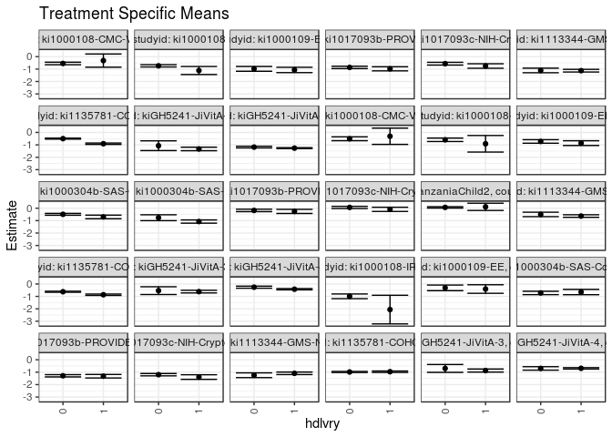

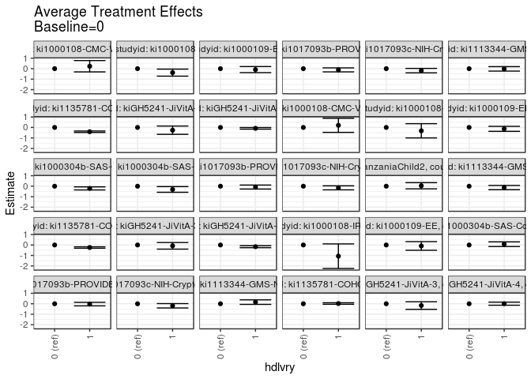

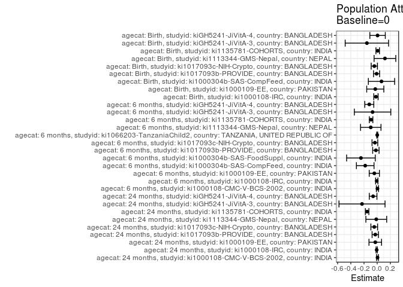

## Results Table

### Parameter: TSM

| agecat | studyid | country | intervention_level | baseline_level | estimate | ci_lower | ci_upper |
| --- | --- | --- | --- | --- | --- | --- | --- |
| Birth | ki1000108-IRC | INDIA | 0 | NA | -0.9918991 | -1.1804921 | -0.8033061 |
| Birth | ki1000108-IRC | INDIA | 1 | NA | -2.0600000 | -3.2141159 | -0.9058841 |
| Birth | ki1000109-EE | PAKISTAN | 0 | NA | -0.3119583 | -0.5379808 | -0.0859359 |
| Birth | ki1000109-EE | PAKISTAN | 1 | NA | -0.4043636 | -0.7491558 | -0.0595715 |
| Birth | ki1000304b-SAS-CompFeed | INDIA | 0 | NA | -0.7224074 | -0.8588900 | -0.5859248 |
| Birth | ki1000304b-SAS-CompFeed | INDIA | 1 | NA | -0.6487750 | -0.8633990 | -0.4341510 |
| Birth | ki1017093b-PROVIDE | BANGLADESH | 0 | NA | -1.2890956 | -1.3804466 | -1.1977446 |
| Birth | ki1017093b-PROVIDE | BANGLADESH | 1 | NA | -1.3234483 | -1.4647493 | -1.1821472 |
| Birth | ki1017093c-NIH-Crypto | BANGLADESH | 0 | NA | -1.2008485 | -1.2944064 | -1.1072907 |
| Birth | ki1017093c-NIH-Crypto | BANGLADESH | 1 | NA | -1.3933962 | -1.5797080 | -1.2070844 |
| Birth | ki1113344-GMS-Nepal | NEPAL | 0 | NA | -1.2453147 | -1.4364070 | -1.0542223 |
| Birth | ki1113344-GMS-Nepal | NEPAL | 1 | NA | -1.0906181 | -1.1918909 | -0.9893453 |
| Birth | ki1135781-COHORTS | INDIA | 0 | NA | -0.9835758 | -1.0278814 | -0.9392702 |
| Birth | ki1135781-COHORTS | INDIA | 1 | NA | -0.9620111 | -1.0195790 | -0.9044431 |
| Birth | kiGH5241-JiVitA-3 | BANGLADESH | 0 | NA | -0.6970370 | -1.0144036 | -0.3796704 |
| Birth | kiGH5241-JiVitA-3 | BANGLADESH | 1 | NA | -0.8691321 | -0.9930986 | -0.7451655 |
| Birth | kiGH5241-JiVitA-4 | BANGLADESH | 0 | NA | -0.6965600 | -0.8356000 | -0.5575200 |
| Birth | kiGH5241-JiVitA-4 | BANGLADESH | 1 | NA | -0.6891879 | -0.7442767 | -0.6340991 |
| 6 months | ki1000108-CMC-V-BCS-2002 | INDIA | 0 | NA | -0.5089262 | -0.6640006 | -0.3538519 |
| 6 months | ki1000108-CMC-V-BCS-2002 | INDIA | 1 | NA | -0.3072917 | -0.9616161 | 0.3470328 |
| 6 months | ki1000108-IRC | INDIA | 0 | NA | -0.5926333 | -0.7305001 | -0.4547666 |
| 6 months | ki1000108-IRC | INDIA | 1 | NA | -0.9137500 | -1.5807163 | -0.2467837 |
| 6 months | ki1000109-EE | PAKISTAN | 0 | NA | -0.7261177 | -0.8682310 | -0.5840045 |
| 6 months | ki1000109-EE | PAKISTAN | 1 | NA | -0.8600964 | -1.0505505 | -0.6696423 |
| 6 months | ki1000304b-SAS-CompFeed | INDIA | 0 | NA | -0.4918367 | -0.5656962 | -0.4179773 |
| 6 months | ki1000304b-SAS-CompFeed | INDIA | 1 | NA | -0.7018119 | -0.8472794 | -0.5563444 |
| 6 months | ki1000304b-SAS-FoodSuppl | INDIA | 0 | NA | -0.7657895 | -1.0028669 | -0.5287120 |
| 6 months | ki1000304b-SAS-FoodSuppl | INDIA | 1 | NA | -1.0737500 | -1.2050138 | -0.9424862 |
| 6 months | ki1017093b-PROVIDE | BANGLADESH | 0 | NA | -0.1791481 | -0.2748721 | -0.0834242 |
| 6 months | ki1017093b-PROVIDE | BANGLADESH | 1 | NA | -0.2577451 | -0.4216605 | -0.0938296 |
| 6 months | ki1017093c-NIH-Crypto | BANGLADESH | 0 | NA | 0.0644404 | -0.0244505 | 0.1533313 |
| 6 months | ki1017093c-NIH-Crypto | BANGLADESH | 1 | NA | -0.0895652 | -0.2594905 | 0.0803601 |
| 6 months | ki1066203-TanzaniaChild2 | TANZANIA, UNITED REPUBLIC OF | 0 | NA | 0.0681546 | 0.0131219 | 0.1231872 |
| 6 months | ki1066203-TanzaniaChild2 | TANZANIA, UNITED REPUBLIC OF | 1 | NA | 0.1114583 | -0.1786966 | 0.4016132 |
| 6 months | ki1113344-GMS-Nepal | NEPAL | 0 | NA | -0.5018605 | -0.6801417 | -0.3235792 |
| 6 months | ki1113344-GMS-Nepal | NEPAL | 1 | NA | -0.6307435 | -0.7327100 | -0.5287770 |
| 6 months | ki1135781-COHORTS | INDIA | 0 | NA | -0.6236913 | -0.6647838 | -0.5825988 |
| 6 months | ki1135781-COHORTS | INDIA | 1 | NA | -0.8646997 | -0.9202754 | -0.8091239 |
| 6 months | kiGH5241-JiVitA-3 | BANGLADESH | 0 | NA | -0.5346154 | -0.8482728 | -0.2209580 |
| 6 months | kiGH5241-JiVitA-3 | BANGLADESH | 1 | NA | -0.6137288 | -0.7215964 | -0.5058612 |
| 6 months | kiGH5241-JiVitA-4 | BANGLADESH | 0 | NA | -0.2563355 | -0.3383123 | -0.1743587 |
| 6 months | kiGH5241-JiVitA-4 | BANGLADESH | 1 | NA | -0.4198311 | -0.4686958 | -0.3709664 |
| 24 months | ki1000108-CMC-V-BCS-2002 | INDIA | 0 | NA | -0.5487673 | -0.6500596 | -0.4474751 |
| 24 months | ki1000108-CMC-V-BCS-2002 | INDIA | 1 | NA | -0.3150000 | -0.8468853 | 0.2168853 |
| 24 months | ki1000108-IRC | INDIA | 0 | NA | -0.7384331 | -0.8312559 | -0.6456103 |
| 24 months | ki1000108-IRC | INDIA | 1 | NA | -1.1158333 | -1.4387631 | -0.7929036 |
| 24 months | ki1000109-EE | PAKISTAN | 0 | NA | -0.9815327 | -1.1744666 | -0.7885988 |
| 24 months | ki1000109-EE | PAKISTAN | 1 | NA | -1.0691515 | -1.2843978 | -0.8539052 |
| 24 months | ki1017093b-PROVIDE | BANGLADESH | 0 | NA | -0.8640762 | -0.9592992 | -0.7688532 |
| 24 months | ki1017093b-PROVIDE | BANGLADESH | 1 | NA | -0.9782534 | -1.1438347 | -0.8126722 |
| 24 months | ki1017093c-NIH-Crypto | BANGLADESH | 0 | NA | -0.5657545 | -0.6762987 | -0.4552102 |
| 24 months | ki1017093c-NIH-Crypto | BANGLADESH | 1 | NA | -0.7521138 | -0.9315086 | -0.5727190 |
| 24 months | ki1113344-GMS-Nepal | NEPAL | 0 | NA | -1.1100565 | -1.2946727 | -0.9254403 |
| 24 months | ki1113344-GMS-Nepal | NEPAL | 1 | NA | -1.1286647 | -1.2351817 | -1.0221477 |
| 24 months | ki1135781-COHORTS | INDIA | 0 | NA | -0.4993270 | -0.5411779 | -0.4574761 |
| 24 months | ki1135781-COHORTS | INDIA | 1 | NA | -0.9084230 | -0.9634403 | -0.8534058 |
| 24 months | kiGH5241-JiVitA-3 | BANGLADESH | 0 | NA | -1.0688235 | -1.4604393 | -0.6772078 |
| 24 months | kiGH5241-JiVitA-3 | BANGLADESH | 1 | NA | -1.3296078 | -1.4712587 | -1.1879570 |
| 24 months | kiGH5241-JiVitA-4 | BANGLADESH | 0 | NA | -1.1804264 | -1.2498465 | -1.1110062 |
| 24 months | kiGH5241-JiVitA-4 | BANGLADESH | 1 | NA | -1.2636575 | -1.3018616 | -1.2254535 |

### Parameter: E(Y)

| agecat | studyid | country | intervention_level | baseline_level | estimate | ci_lower | ci_upper |
| --- | --- | --- | --- | --- | --- | --- | --- |
| Birth | ki1000108-IRC | INDIA | NA | NA | -1.0105831 | -1.1973019 | -0.8238643 |
| Birth | ki1000109-EE | PAKISTAN | NA | NA | -0.3410000 | -0.5302198 | -0.1517802 |
| Birth | ki1000304b-SAS-CompFeed | INDIA | NA | NA | -0.6570846 | -0.8496671 | -0.4645022 |
| Birth | ki1017093b-PROVIDE | BANGLADESH | NA | NA | -1.2984586 | -1.3752758 | -1.2216415 |
| Birth | ki1017093c-NIH-Crypto | BANGLADESH | NA | NA | -1.2441513 | -1.3281130 | -1.1601897 |
| Birth | ki1113344-GMS-Nepal | NEPAL | NA | NA | -1.1277349 | -1.2174865 | -1.0379833 |
| Birth | ki1135781-COHORTS | INDIA | NA | NA | -0.9755867 | -1.0106993 | -0.9404741 |
| Birth | kiGH5241-JiVitA-3 | BANGLADESH | NA | NA | -0.8532192 | -0.9644938 | -0.7419446 |
| Birth | kiGH5241-JiVitA-4 | BANGLADESH | NA | NA | -0.6907341 | -0.7437042 | -0.6377640 |
| 6 months | ki1000108-CMC-V-BCS-2002 | INDIA | NA | NA | -0.5045068 | -0.6566169 | -0.3523968 |
| 6 months | ki1000108-IRC | INDIA | NA | NA | -0.5989297 | -0.7344491 | -0.4634104 |
| 6 months | ki1000109-EE | PAKISTAN | NA | NA | -0.7695800 | -0.8839306 | -0.6552294 |
| 6 months | ki1000304b-SAS-CompFeed | INDIA | NA | NA | -0.6734421 | -0.8121314 | -0.5347528 |
| 6 months | ki1000304b-SAS-FoodSuppl | INDIA | NA | NA | -1.0121579 | -1.1280429 | -0.8962729 |
| 6 months | ki1017093b-PROVIDE | BANGLADESH | NA | NA | -0.1990907 | -0.2817968 | -0.1163845 |
| 6 months | ki1017093c-NIH-Crypto | BANGLADESH | NA | NA | 0.0297622 | -0.0491685 | 0.1086930 |
| 6 months | ki1066203-TanzaniaChild2 | TANZANIA, UNITED REPUBLIC OF | NA | NA | 0.0688763 | 0.0147308 | 0.1230218 |
| 6 months | ki1113344-GMS-Nepal | NEPAL | NA | NA | -0.5992551 | -0.6878945 | -0.5106156 |
| 6 months | ki1135781-COHORTS | INDIA | NA | NA | -0.7160077 | -0.7492815 | -0.6827338 |
| 6 months | kiGH5241-JiVitA-3 | BANGLADESH | NA | NA | -0.6044910 | -0.7122040 | -0.4967781 |
| 6 months | kiGH5241-JiVitA-4 | BANGLADESH | NA | NA | -0.3760651 | -0.4191017 | -0.3330285 |
| 24 months | ki1000108-CMC-V-BCS-2002 | INDIA | NA | NA | -0.5436992 | -0.6434110 | -0.4439874 |
| 24 months | ki1000108-IRC | INDIA | NA | NA | -0.7458150 | -0.8368180 | -0.6548120 |
| 24 months | ki1000109-EE | PAKISTAN | NA | NA | -1.0103892 | -1.1580613 | -0.8627171 |
| 24 months | ki1017093b-PROVIDE | BANGLADESH | NA | NA | -0.8928670 | -0.9755153 | -0.8102187 |
| 24 months | ki1017093c-NIH-Crypto | BANGLADESH | NA | NA | -0.6103502 | -0.7050157 | -0.5156847 |
| 24 months | ki1113344-GMS-Nepal | NEPAL | NA | NA | -1.1238388 | -1.2161263 | -1.0315513 |
| 24 months | ki1135781-COHORTS | INDIA | NA | NA | -0.6520577 | -0.6860033 | -0.6181122 |
| 24 months | kiGH5241-JiVitA-3 | BANGLADESH | NA | NA | -1.2989273 | -1.4377964 | -1.1600583 |
| 24 months | kiGH5241-JiVitA-4 | BANGLADESH | NA | NA | -1.2421463 | -1.2763113 | -1.2079812 |

### Parameter: ATE

| agecat | studyid | country | intervention_level | baseline_level | estimate | ci_lower | ci_upper |
| --- | --- | --- | --- | --- | --- | --- | --- |
| Birth | ki1000108-IRC | INDIA | 0 | 0 | 0.0000000 | 0.0000000 | 0.0000000 |
| Birth | ki1000108-IRC | INDIA | 1 | 0 | -1.0681009 | -2.2375241 | 0.1013224 |
| Birth | ki1000109-EE | PAKISTAN | 0 | 0 | 0.0000000 | 0.0000000 | 0.0000000 |
| Birth | ki1000109-EE | PAKISTAN | 1 | 0 | -0.0924053 | -0.5046768 | 0.3198662 |
| Birth | ki1000304b-SAS-CompFeed | INDIA | 0 | 0 | 0.0000000 | 0.0000000 | 0.0000000 |
| Birth | ki1000304b-SAS-CompFeed | INDIA | 1 | 0 | 0.0736324 | -0.1488189 | 0.2960837 |
| Birth | ki1017093b-PROVIDE | BANGLADESH | 0 | 0 | 0.0000000 | 0.0000000 | 0.0000000 |
| Birth | ki1017093b-PROVIDE | BANGLADESH | 1 | 0 | -0.0343527 | -0.2026114 | 0.1339061 |
| Birth | ki1017093c-NIH-Crypto | BANGLADESH | 0 | 0 | 0.0000000 | 0.0000000 | 0.0000000 |
| Birth | ki1017093c-NIH-Crypto | BANGLADESH | 1 | 0 | -0.1925477 | -0.4010307 | 0.0159353 |
| Birth | ki1113344-GMS-Nepal | NEPAL | 0 | 0 | 0.0000000 | 0.0000000 | 0.0000000 |
| Birth | ki1113344-GMS-Nepal | NEPAL | 1 | 0 | 0.1546966 | -0.0615728 | 0.3709660 |
| Birth | ki1135781-COHORTS | INDIA | 0 | 0 | 0.0000000 | 0.0000000 | 0.0000000 |
| Birth | ki1135781-COHORTS | INDIA | 1 | 0 | 0.0215648 | -0.0510786 | 0.0942081 |
| Birth | kiGH5241-JiVitA-3 | BANGLADESH | 0 | 0 | 0.0000000 | 0.0000000 | 0.0000000 |
| Birth | kiGH5241-JiVitA-3 | BANGLADESH | 1 | 0 | -0.1720950 | -0.5344752 | 0.1902851 |
| Birth | kiGH5241-JiVitA-4 | BANGLADESH | 0 | 0 | 0.0000000 | 0.0000000 | 0.0000000 |
| Birth | kiGH5241-JiVitA-4 | BANGLADESH | 1 | 0 | 0.0073721 | -0.1409622 | 0.1557064 |
| 6 months | ki1000108-CMC-V-BCS-2002 | INDIA | 0 | 0 | 0.0000000 | 0.0000000 | 0.0000000 |
| 6 months | ki1000108-CMC-V-BCS-2002 | INDIA | 1 | 0 | 0.2016346 | -0.4708151 | 0.8740843 |
| 6 months | ki1000108-IRC | INDIA | 0 | 0 | 0.0000000 | 0.0000000 | 0.0000000 |
| 6 months | ki1000108-IRC | INDIA | 1 | 0 | -0.3211167 | -1.0021830 | 0.3599496 |
| 6 months | ki1000109-EE | PAKISTAN | 0 | 0 | 0.0000000 | 0.0000000 | 0.0000000 |
| 6 months | ki1000109-EE | PAKISTAN | 1 | 0 | -0.1339787 | -0.3716106 | 0.1036533 |
| 6 months | ki1000304b-SAS-CompFeed | INDIA | 0 | 0 | 0.0000000 | 0.0000000 | 0.0000000 |
| 6 months | ki1000304b-SAS-CompFeed | INDIA | 1 | 0 | -0.2099752 | -0.3568133 | -0.0631371 |
| 6 months | ki1000304b-SAS-FoodSuppl | INDIA | 0 | 0 | 0.0000000 | 0.0000000 | 0.0000000 |
| 6 months | ki1000304b-SAS-FoodSuppl | INDIA | 1 | 0 | -0.3079605 | -0.5789511 | -0.0369700 |
| 6 months | ki1017093b-PROVIDE | BANGLADESH | 0 | 0 | 0.0000000 | 0.0000000 | 0.0000000 |
| 6 months | ki1017093b-PROVIDE | BANGLADESH | 1 | 0 | -0.0785969 | -0.2684162 | 0.1112223 |
| 6 months | ki1017093c-NIH-Crypto | BANGLADESH | 0 | 0 | 0.0000000 | 0.0000000 | 0.0000000 |
| 6 months | ki1017093c-NIH-Crypto | BANGLADESH | 1 | 0 | -0.1540057 | -0.3457769 | 0.0377656 |
| 6 months | ki1066203-TanzaniaChild2 | TANZANIA, UNITED REPUBLIC OF | 0 | 0 | 0.0000000 | 0.0000000 | 0.0000000 |
| 6 months | ki1066203-TanzaniaChild2 | TANZANIA, UNITED REPUBLIC OF | 1 | 0 | 0.0433038 | -0.2520240 | 0.3386315 |
| 6 months | ki1113344-GMS-Nepal | NEPAL | 0 | 0 | 0.0000000 | 0.0000000 | 0.0000000 |
| 6 months | ki1113344-GMS-Nepal | NEPAL | 1 | 0 | -0.1288831 | -0.3342641 | 0.0764979 |
| 6 months | ki1135781-COHORTS | INDIA | 0 | 0 | 0.0000000 | 0.0000000 | 0.0000000 |
| 6 months | ki1135781-COHORTS | INDIA | 1 | 0 | -0.2410084 | -0.3101261 | -0.1718907 |
| 6 months | kiGH5241-JiVitA-3 | BANGLADESH | 0 | 0 | 0.0000000 | 0.0000000 | 0.0000000 |
| 6 months | kiGH5241-JiVitA-3 | BANGLADESH | 1 | 0 | -0.0791134 | -0.3927103 | 0.2344834 |
| 6 months | kiGH5241-JiVitA-4 | BANGLADESH | 0 | 0 | 0.0000000 | 0.0000000 | 0.0000000 |
| 6 months | kiGH5241-JiVitA-4 | BANGLADESH | 1 | 0 | -0.1634956 | -0.2569226 | -0.0700686 |
| 24 months | ki1000108-CMC-V-BCS-2002 | INDIA | 0 | 0 | 0.0000000 | 0.0000000 | 0.0000000 |
| 24 months | ki1000108-CMC-V-BCS-2002 | INDIA | 1 | 0 | 0.2337673 | -0.3076771 | 0.7752117 |
| 24 months | ki1000108-IRC | INDIA | 0 | 0 | 0.0000000 | 0.0000000 | 0.0000000 |
| 24 months | ki1000108-IRC | INDIA | 1 | 0 | -0.3774002 | -0.7134057 | -0.0413948 |
| 24 months | ki1000109-EE | PAKISTAN | 0 | 0 | 0.0000000 | 0.0000000 | 0.0000000 |
| 24 months | ki1000109-EE | PAKISTAN | 1 | 0 | -0.0876188 | -0.3766766 | 0.2014391 |
| 24 months | ki1017093b-PROVIDE | BANGLADESH | 0 | 0 | 0.0000000 | 0.0000000 | 0.0000000 |
| 24 months | ki1017093b-PROVIDE | BANGLADESH | 1 | 0 | -0.1141772 | -0.3051866 | 0.0768321 |
| 24 months | ki1017093c-NIH-Crypto | BANGLADESH | 0 | 0 | 0.0000000 | 0.0000000 | 0.0000000 |
| 24 months | ki1017093c-NIH-Crypto | BANGLADESH | 1 | 0 | -0.1863593 | -0.3970784 | 0.0243597 |
| 24 months | ki1113344-GMS-Nepal | NEPAL | 0 | 0 | 0.0000000 | 0.0000000 | 0.0000000 |
| 24 months | ki1113344-GMS-Nepal | NEPAL | 1 | 0 | -0.0186082 | -0.2317490 | 0.1945327 |
| 24 months | ki1135781-COHORTS | INDIA | 0 | 0 | 0.0000000 | 0.0000000 | 0.0000000 |
| 24 months | ki1135781-COHORTS | INDIA | 1 | 0 | -0.4090960 | -0.4782220 | -0.3399701 |
| 24 months | kiGH5241-JiVitA-3 | BANGLADESH | 0 | 0 | 0.0000000 | 0.0000000 | 0.0000000 |
| 24 months | kiGH5241-JiVitA-3 | BANGLADESH | 1 | 0 | -0.2607843 | -0.6565783 | 0.1350097 |
| 24 months | kiGH5241-JiVitA-4 | BANGLADESH | 0 | 0 | 0.0000000 | 0.0000000 | 0.0000000 |
| 24 months | kiGH5241-JiVitA-4 | BANGLADESH | 1 | 0 | -0.0832312 | -0.1611211 | -0.0053413 |

### Parameter: PAR

| agecat | studyid | country | intervention_level | baseline_level | estimate | ci_lower | ci_upper |
| --- | --- | --- | --- | --- | --- | --- | --- |
| Birth | ki1000108-IRC | INDIA | 0 | NA | -0.0186840 | -0.0514705 | 0.0141025 |
| Birth | ki1000109-EE | PAKISTAN | 0 | NA | -0.0290417 | -0.1587694 | 0.1006861 |
| Birth | ki1000304b-SAS-CompFeed | INDIA | 0 | NA | 0.0653228 | -0.1338606 | 0.2645061 |
| Birth | ki1017093b-PROVIDE | BANGLADESH | 0 | NA | -0.0093630 | -0.0552415 | 0.0365154 |
| Birth | ki1017093c-NIH-Crypto | BANGLADESH | 0 | NA | -0.0433028 | -0.0905629 | 0.0039573 |
| Birth | ki1113344-GMS-Nepal | NEPAL | 0 | NA | 0.1175798 | -0.0468852 | 0.2820448 |
| Birth | ki1135781-COHORTS | INDIA | 0 | NA | 0.0079891 | -0.0189249 | 0.0349032 |
| Birth | kiGH5241-JiVitA-3 | BANGLADESH | 0 | NA | -0.1561821 | -0.4851685 | 0.1728042 |
| Birth | kiGH5241-JiVitA-4 | BANGLADESH | 0 | NA | 0.0058259 | -0.1114003 | 0.1230522 |
| 6 months | ki1000108-CMC-V-BCS-2002 | INDIA | 0 | NA | 0.0044194 | -0.0126632 | 0.0215020 |
| 6 months | ki1000108-IRC | INDIA | 0 | NA | -0.0062964 | -0.0238639 | 0.0112711 |
| 6 months | ki1000109-EE | PAKISTAN | 0 | NA | -0.0434623 | -0.1208123 | 0.0338878 |
| 6 months | ki1000304b-SAS-CompFeed | INDIA | 0 | NA | -0.1816054 | -0.3152754 | -0.0479353 |
| 6 months | ki1000304b-SAS-FoodSuppl | INDIA | 0 | NA | -0.2463684 | -0.4635153 | -0.0292215 |
| 6 months | ki1017093b-PROVIDE | BANGLADESH | 0 | NA | -0.0199425 | -0.0681830 | 0.0282980 |
| 6 months | ki1017093c-NIH-Crypto | BANGLADESH | 0 | NA | -0.0346782 | -0.0781173 | 0.0087609 |
| 6 months | ki1066203-TanzaniaChild2 | TANZANIA, UNITED REPUBLIC OF | 0 | NA | 0.0007217 | -0.0066656 | 0.0081091 |
| 6 months | ki1113344-GMS-Nepal | NEPAL | 0 | NA | -0.0973946 | -0.2526693 | 0.0578801 |
| 6 months | ki1135781-COHORTS | INDIA | 0 | NA | -0.0923164 | -0.1190027 | -0.0656300 |
| 6 months | kiGH5241-JiVitA-3 | BANGLADESH | 0 | NA | -0.0698756 | -0.3463935 | 0.2066422 |
| 6 months | kiGH5241-JiVitA-4 | BANGLADESH | 0 | NA | -0.1197296 | -0.1882597 | -0.0511994 |
| 24 months | ki1000108-CMC-V-BCS-2002 | INDIA | 0 | NA | 0.0050681 | -0.0089078 | 0.0190440 |
| 24 months | ki1000108-IRC | INDIA | 0 | NA | -0.0073819 | -0.0171941 | 0.0024303 |
| 24 months | ki1000109-EE | PAKISTAN | 0 | NA | -0.0288565 | -0.1242611 | 0.0665481 |
| 24 months | ki1017093b-PROVIDE | BANGLADESH | 0 | NA | -0.0287908 | -0.0771248 | 0.0195432 |
| 24 months | ki1017093c-NIH-Crypto | BANGLADESH | 0 | NA | -0.0445957 | -0.0954880 | 0.0062965 |
| 24 months | ki1113344-GMS-Nepal | NEPAL | 0 | NA | -0.0137823 | -0.1716489 | 0.1440842 |
| 24 months | ki1135781-COHORTS | INDIA | 0 | NA | -0.1527307 | -0.1793503 | -0.1261112 |
| 24 months | kiGH5241-JiVitA-3 | BANGLADESH | 0 | NA | -0.2301038 | -0.5792963 | 0.1190887 |
| 24 months | kiGH5241-JiVitA-4 | BANGLADESH | 0 | NA | -0.0617199 | -0.1195592 | -0.0038806 |